# SOCM034- Assignment_3-20210607

Philipp Holz

6/7/2021

First step: Getting the data ready.

Visualise time series objects. What seems to be correlated?

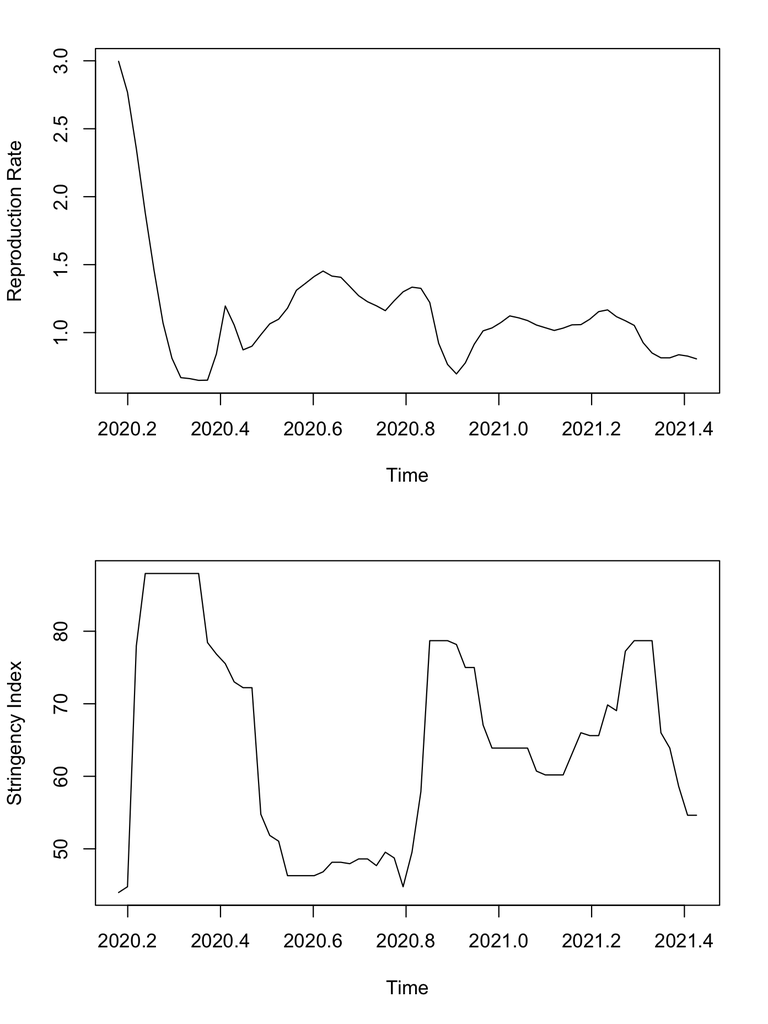

Let’s check, if the series are stationary.

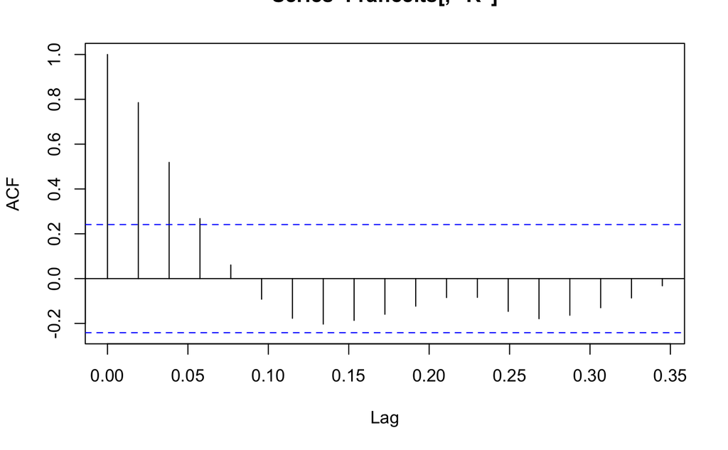

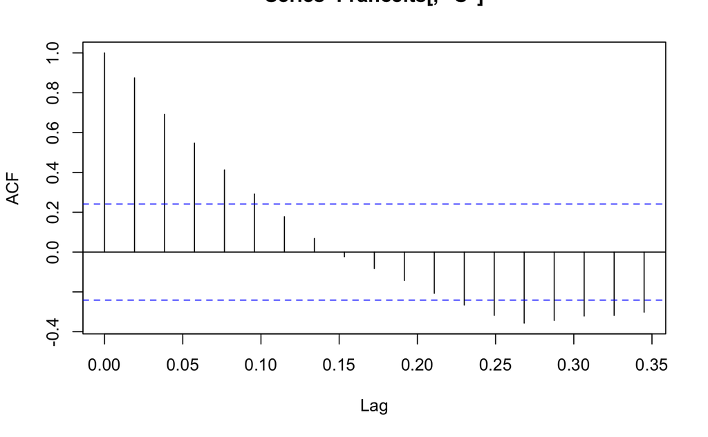

No, they are not. Let’s see, if we can achieve more stationarity by differencing the time series.

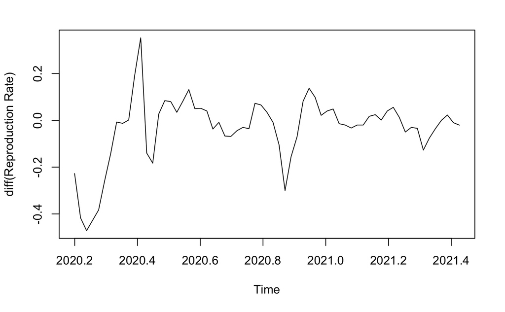

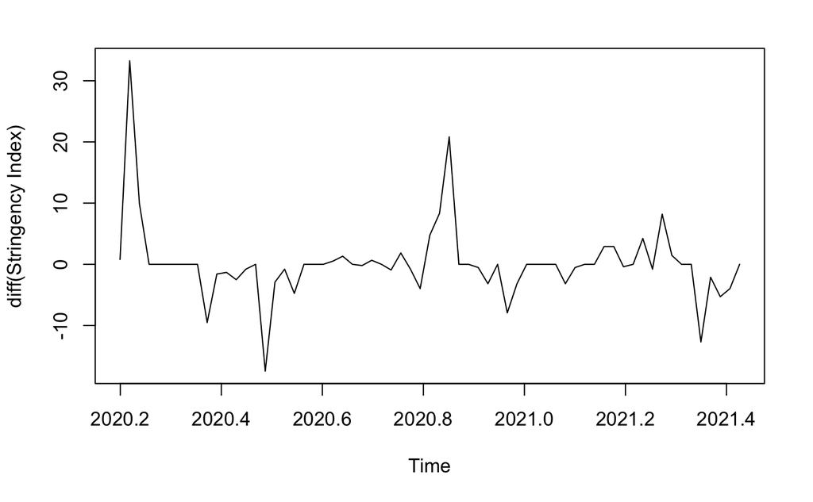

Looks like it! Let’s test that again with the correlogram.

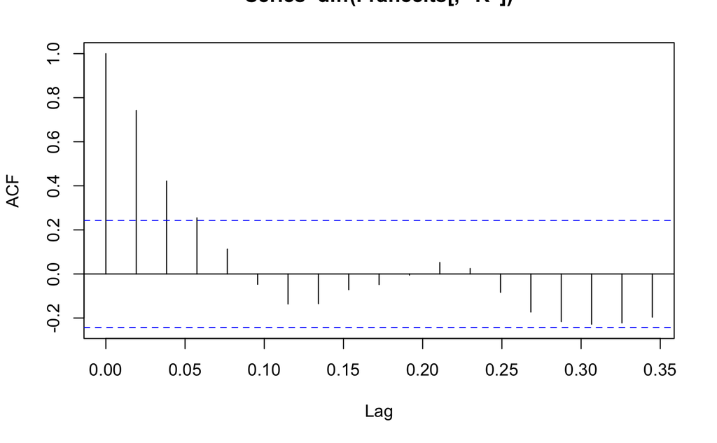

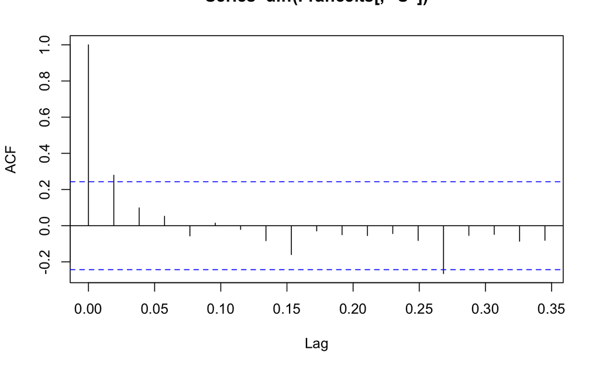

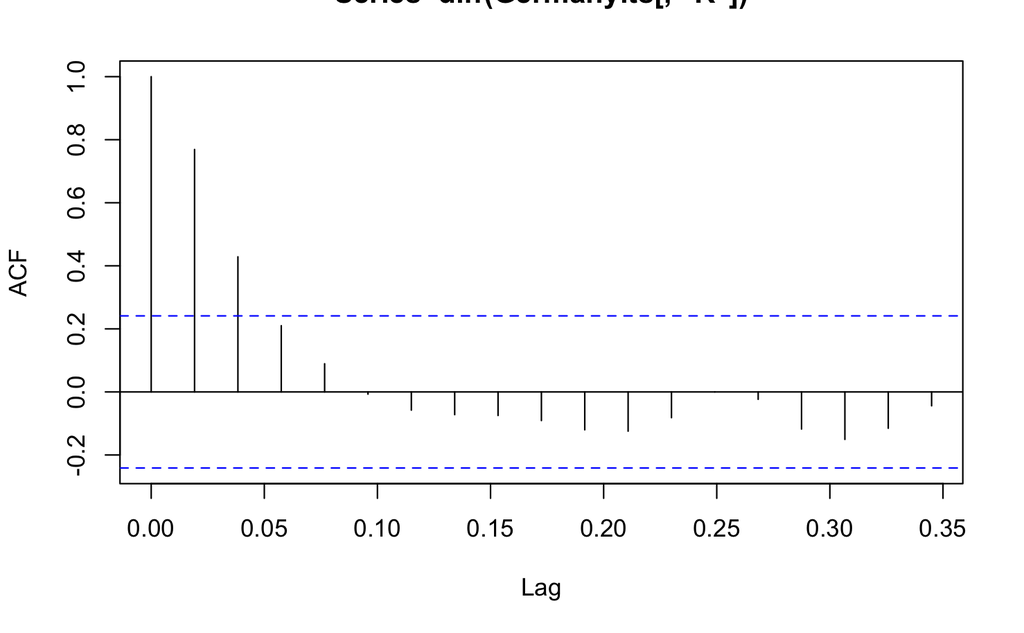

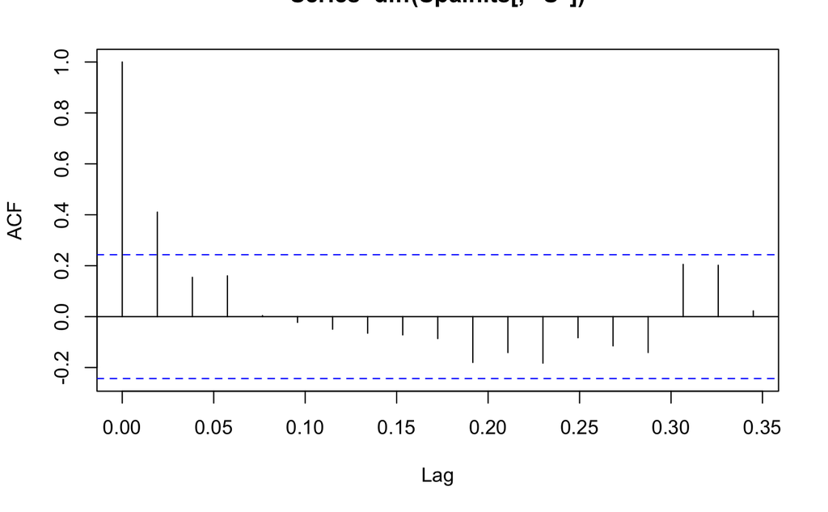

It seems we have to fit an autoregressive distributed lag model, to account for the autocorrelation in the dependent variable.